# 02.06.00.00.RelatividadGeneral.Curvatura

Indice | Previo: RelatividadGeneral.InerciaYGeodesicas | Siguiente: RelatividadGeneral.PrincipioConsistencia

## Transporte paralelo y curvatura {#tparalelo_curvatura}

En una sección anterior vimos dos situaciones diferentes en el transporte paralelo: en espacio plano y en espacio curvo (ver figuras abajo) y un hecho es notable: al recorrer una trayectoria cerrada en el espacio plano un vector transportado de forma paralela no se modifica. Sin embargo en otro tipo de espacio (sobre la superficie de una esfera), sobre una trayectoria circular un vector transportado de forma paralela no vuelve a ser lo mismo.

[figure not shown]

**Figura 2.43**. Figura

**Figura 2.43**. Figura

Más allá de eso, inclusive, el vetor transportado por dos caminos diferentes no es el mismo al finalizar el camino como se muestra en la figura:

[figure not shown]

**Figura 2.44**. Transporte paralelo sobre una esfera

¿Por qué ocurre esto? ¿de qué depende?

Otra manera de expresar la diferencia es decir que el vector transportado de forma paralela depene del camino que se siga. En la figura se muestra el transporte paralelo de un vector $A^\mu$ desde un punto $P$ hasta un punto $Q$ por dos caminos diferentes $\mathrm{d}x^\alpha\rightarrow \mathrm{d}x^\beta$ y $\mathrm{d}x^\beta\rightarrow \mathrm{d}x^\alpha$

[figure not shown]

**Figura 2.45**. Figura

La diferencia a través de los dos recorridos la hemos llamado $\mathrm{d}^2A^\mu$.

Usemos la derivada covariante para el transporte paralelo hasta los puntos intermedios $R$ y $S$:

$$ A^\mu_{\parallel,\mathrm{R}}=A^\mu+\mathrm{D}_\beta A^\mu \mathrm{d}x^\beta $$

Ror otro lado es transporte de $R$ a $Q$ es:

$$ A^\mu_{\parallel,\mathrm{RQ}}=A^\mu_{\parallel,\mathrm{R}}+\mathrm{D}_\alpha A^\mu_{\parallel,\mathrm{R}} \mathrm{d}x^\alpha $$

reemplazando lo obtenido antes obtenemos:

$$ A^\mu_{\parallel,\mathrm{RQ}}=A^\mu+\mathrm{D}_\beta A^\mu \mathrm{d}x^\beta+\mathrm{D}_\alpha A^\mu \mathrm{d}x^\alpha+\mathrm{D}_{\alpha\beta} A^\mu \mathrm{d}x^\alpha\mathrm{d}x^\beta $$

El recorrido por el otro recorrido es:

$$ A^\mu_{\parallel,\mathrm{SQ}}=A^\mu+\mathrm{D}_\alpha A^\mu \mathrm{d}x^\alpha+\mathrm{D}_\beta A^\mu \mathrm{d}x^\beta+\mathrm{D}_{\beta\alpha} A^\mu \mathrm{d}x^\alpha\mathrm{d}x^\beta $$

Tomando la diferencia obtenemos:

$$ \mathrm{d}^2 A^\mu=A^\mu_{\parallel,\mathrm{SQ}}-A^\mu_{\parallel,\mathrm{RQ}}=-(\mathrm{D}_{\alpha\beta}-\mathrm{D}_{\beta\alpha}) A^\mu \mathrm{d}x^\alpha\mathrm{d}x^\beta $$

Por otro lado podemos suponer que la diferencia entre el vector transportado por los dos caminos se puede expresar como:

$$ \mathrm{d}^2 A^\mu\equiv {R^\mu}_{\delta\alpha\beta}A^\delta \mathrm{d}x^\alpha\mathrm{d}x^\beta $$

donde los nuevos coeficientes $R^\mu_{\delta\alpha\beta}$ juegan el papel que en el transporte paralelo convencional jugaban los coeficientes de conexión.

Comparando encontramos que la manera de cálcular los coeficientes es:

$$ {R^\mu}_{\delta\alpha\beta}A^\delta=-(\mathrm{D}_{\alpha\beta}-\mathrm{D}_{\beta\alpha}) A^\mu $$

O en la notación punto y coma de la derivada covariante:

$$ {R^\mu}_{\delta\alpha\beta}A^\delta=-(A^\mu_{;\alpha;\beta}- A^\mu_{;\beta;\alpha}) $$

Veamos cómo es la segunda derivada covariante:

$$ \begin{array}{rcl} {A^\rho}_{;\mu;\nu} & = & ({A^\rho}_{;\nu,\mu}) +[\Gamma_{\mu\sigma}^\rho {A^\sigma}_{;\nu}] -\{\Gamma_{\mu\nu}^\lambda {A^\rho}_{;\lambda}\}\\ &=&({A^\rho}_{,\nu,\mu}+\Gamma^\rho_{\nu\sigma,\mu}A^\sigma+\Gamma^\rho_{\nu\sigma}{A^\sigma}_{,\mu})+\\ & & +[\Gamma_{\mu\sigma}^\rho {A^\sigma}_{,\nu}+\Gamma_{\mu\sigma}^\rho \Gamma_{\nu\lambda}^\sigma A^\lambda]+\\ & & -\{\Gamma_{\mu\nu}^\lambda {A^\rho}_{,\lambda}+\Gamma_{\mu\nu}^\lambda \Gamma_{\lambda\sigma}^\rho A^\sigma\} \end{array} $$

La derivada contraria ${A^\rho}_{;\nu;\mu}$ se obtiene intercambiando en la expresión anterior $\mu\leftrightarrow\nu$. Es claro que los términos proporcionales a $\Gamma_{\mu\nu}^\lambda$ serán idénticos en ambas derivadas y se eliminaran. Lo mismo pasa con los términos ${A^\rho}_{,\nu,\mu}$ y $\Gamma^\rho_{\nu\sigma}{A^\sigma}_{,\mu}$ y $\Gamma_{\mu\sigma}^\rho {A^\sigma}_{,\nu}$ que serán idénticos a los correspondientes en la derivada con los índices cambiados.

De modo que nos queda:

$$ A^\sigma_{;\mu;\nu}- A^\sigma_{;\nu;\mu}=(\{\Gamma^\rho_{\nu\sigma,\mu} + \Gamma_{\mu\delta}^\rho \Gamma_{\nu\sigma}^\delta\}-\{\mu\leftrightarrow\nu\})A^\sigma $$

donde la notación $\{\mu\leftrightarrow\nu\}$ indica que lo que hay antes entre llaves se pone igual pero intercambiando los índices $\mu$ por $\nu$ y viceversa.

Volviendo a la definición de los coeficientes $R$ obtenemos entonces que ellos están dados como función de los símbolos de Christoffel y de sus derivadas en la forma más conveniente:

$$ {R^\rho}_{\sigma\mu\nu}=\{\Gamma^\rho_{\sigma\mu,\nu} + \Gamma_{\sigma\mu}^\delta \Gamma_{\nu\delta}^\rho \}-\{\mu\leftrightarrow\nu\} $$

Esta cantidad transforma como un tensor (ver Problemas al final del capítulo) y se conoce como el **tensor de Riemann**.

De acuerdo a lo que habíamos dicho antes, el tensor de Riemann establece si un espacio es curvo o no. Esta condición puede expresarse de dos maneras:

- Si **al menos una** de las componentes del tensor de Riemann es distinta de cero, **el espacio es curvo**.
- Si **todas** las componentes del tensor de Riemann son cero, **el espacio es plano**.

**Nota: La arbitrariedad en la elección del signo del tensor de Riemann.** Nótese que en la definición del tensor de Riemann que hemos hecho aquí la elección de como comparamos un vector transportado de forma paralela por un camino o por otro ha sido más bien arbitraria. Por esta misma razón el signo del tensor de Riemann es también arbitrario y depende de la elección que haga cada autor.

> Hay dos posibilidades: la que hemos usado aquí,

> $$ {R^\rho}_{\sigma\mu\nu}=\{\Gamma^\rho_{\sigma\mu,\nu} + \Gamma_{\sigma\mu}^\delta \Gamma_{\nu\delta}^\rho \}-\{\mu\leftrightarrow\nu\} $$

> esta elección tiene la ventaja de que el orden de los índices en el tensor de Riemann y en el primer término al lado derecho es exactamente la misma. Eso ayuda a recordar el tensor.

> O bien la que usan muchos otros autores:

> $$ {{\cal R}^\rho}_{\sigma\mu\nu}=\{\Gamma^\rho_{\sigma\nu,\mu} + \Gamma_{\sigma\nu}^\delta \Gamma_{\mu\delta}^\rho \}-\{\mu\leftrightarrow\nu\} $$

### 2.8.6. Propiedades del tensor de Riemann

El tensor de Riemann juega un papel fundamental en la relatividad general de modo que sus propiedades son cruciales para las matemáticas del área.

La primera propiedad y la más obvia es su antisimetría:

$$ {R^\rho}_{\sigma\mu\nu}=-{R^\rho}_{\sigma\nu\mu}\\ {R^\rho}_{\sigma\mu\nu}+{R^\rho}_{\sigma\nu\mu}=0 $$

que podemos escribir también como:

$$ {R^\rho}_{\sigma[\mu\nu]}=0 $$

¿Cuántas componentes tiene el tensor de Riemann?

De la misma manera que los símbolos de Christoffel pueden ser pensados como una "pila de matrices", el tensor de Riemann es como una matriz de matrices:

$$ {R^\rho}_{\sigma\mu\nu}=({R^\rho}_\sigma)_{\mu\nu} $$

de donde sabemos que en total el número de componentes totales será $N^4$ y para el espacio-tiempo 256 componentes.

Ahora bien, por la antisimetría de $\mu\nu$ sabemos que la diagonal:

$$({R^\rho}_\sigma)_{\mu\mu}=0$$

y por lo tanto cada matriz de matrices tiene por lo menos $N(N-1)/2$ componentes independientes, para un total de $N^3(N-1)/2$ que en el caso de $N=4$ corresponde a 96 componentes independientes.

El número de términos encontrados es todavía muy grande, pero puede mostrarse que es menos si se baja el índice superior:

$$ R_{\lambda\mu\nu\kappa}=g_{\lambda\rho}{R^{\rho}}_{\mu\nu\kappa} $$

Desarrollando en detalle se puede mostrar (ver Problemas al final del capítulo) que esta versión totalmente covariante del tensor de Riemann es:

$$ \begin{array}{rcl} R_{\lambda\mu\nu\kappa} & = & -\frac{1}{2}(g_{\mu\nu,\lambda,\kappa}-g_{\nu\lambda,\kappa,\mu}+g_{\lambda\kappa,\mu,\nu}-g_{\kappa\mu,\nu,\lambda})+\\ & & +g_{\sigma\xi}(\Gamma^\sigma_{\mu\kappa}\Gamma^\xi_{\lambda\nu}-\Gamma^\sigma_{\mu\nu}\Gamma^\xi_{\lambda\kappa}) \end{array} $$

O en notación más compacta:

$$ R_{\lambda\mu\nu\kappa} = -\frac{1}{2} g_{\{\mu\nu,\lambda,\kappa\}}-g_{\alpha\beta}(\Gamma^\alpha_{\mu\nu}\Gamma^\beta_{\lambda\kappa}-\Gamma^\alpha_{\mu\kappa}\Gamma^\beta_{\lambda\nu}) $$

Es decir el tensor de Riemann es proporcional a las **segundas derivadas de la métrica**.

**Nota: Recordando los índices del tensor de Riemann.** Existen dos maneras de escribir los índices del tensor de Riemann para recordar más fácil su definición: $\lambda\mu\nu\kappa$ y $\alpha\beta\mu\nu$. Aquí los índices $\mu\nu$ juegan el papel de índices de referencia para recordar las posiciones de los índices en la expresión final.

> Para la definición y el cálculo, es más conveniente escribirlos en el orden $\lambda\mu\nu\kappa$. Con esta convención se puede recordar que las derivadas de la métrica inicialmente son con respecto a los índices $\lambda$ y $\kappa$:

> $$ R_{\lambda\mu\nu\kappa} = -\frac{1}{2} g_{\{\mu\nu,\lambda,\kappa\}}-\ldots $$

> Sin embargo, para probar algunas de las identidades más interesantes del tensor, es mejor el orden $\alpha\beta\mu\nu$:

> $$ R_{\alpha\beta\mu\nu} = -\frac{1}{2} g_{\{\beta\mu,\alpha,\nu\}}-g_{\sigma\gamma}(\Gamma^\sigma_{\beta\mu}\Gamma^\gamma_{\alpha\nu}-\Gamma^\sigma_{\beta\nu}\Gamma^\gamma_{\alpha\mu}) $$

Con esta expresión se identifica dos propiedades:

1. Antisimetría frente al intercambio de los primeros indices: $$ R_{\alpha\beta\mu\nu}=-R_{\beta\alpha\mu\nu} $$
2. Simetría frente al intercambio de los pares de índices inicial y final:

   $$ R_{\alpha\beta\mu\nu}=R_{\mu\nu\beta\alpha} $$

De modo que tenemos una matriz antisimétrica de matrices antisimétricas. Eso implica que hay $M=N(N-1)/2$ matrices antisimétricas de $M=N(N-1)/2$ términos, es decir $N^2(N-1)^2/4$, para $N=4$ el número de términos es $4^2(4-1)^2/4=36$ términos independientes. Esos términos son:

$$ \begin{array}{cccccc} R_{0101}&R_{0102}&R_{0103}&R_{0112}&R_{0113}&R_{0123}\\ R_{0201}&R_{0202}&R_{0203}&R_{0212}&R_{0213}&R_{0223}\\ R_{0301}&R_{0302}&R_{0303}&R_{0312}&R_{0313}&R_{0323}\\ R_{1201}&R_{1202}&R_{1203}&R_{1212}&R_{1213}&R_{1223}\\ R_{1301}&R_{1302}&R_{1303}&R_{1312}&R_{1313}&R_{1323}\\ R_{2301}&R_{2302}&R_{2303}&R_{2312}&R_{2313}& R_{2323}\\ \end{array} $$

Pero por la propiedad 2 de más arriba, este arreglo cuadrado de términos es simétrico y por lo tanto de todos estos términos hay $6(6+1)/2=21$ términos independientes.

La conclusión hasta ahora es que para que las componentes del tensor de Riemann que sean independientes y potencialmente distintas de 0 **los primeros indíces y los últimos deben ser diferentes entre sí**. Las componentes $R_{\alpha\alpha\mu\nu}$ o $R_{\alpha\beta\mu\mu}$ son siempre iguales a cero.

**Proposición: Identidades de Bianchi.** Hay dos propiedades adicionales del tensor de Riemann que pueden llegar a ser de alguna utilidad:

> 1. **Primera identidad de Bianchi**: $R_{\alpha[\beta\mu\nu]}=0$
> 2. **Segunda identidad de Bianchi**: ${R^{\alpha}}_{\beta[\mu\nu;\sigma]}=0$

### 2.8.7. Tensor de Riemann para métricas diagonales

Pensemos ahora nuevamente en el caso en el que la métrica es simétrica. En este caso el tensor de Riemann se simplifica de un general:

$$ R_{\lambda\mu\nu\kappa} = -\frac{1}{2} g_{\{\mu\nu,\lambda,\kappa\}}-g_{\alpha\beta}(\Gamma^\alpha_{\mu\nu}\Gamma^\beta_{\lambda\kappa}-\Gamma^\alpha_{\mu\kappa}\Gamma^\beta_{\lambda\nu}) $$

a uno más particular:

$$ R_{\lambda\mu\nu\kappa} = -\frac{1}{2} g_{\{\mu\nu,\lambda,\kappa\}}-g_{\alpha\alpha}(\Gamma^\alpha_{\mu\nu}\Gamma^\alpha_{\lambda\kappa}-\Gamma^\alpha_{\mu\kappa}\Gamma^\alpha_{\lambda\nu}) $$

De estos aquellos con $\mu=\nu$ y $\lambda\neq \kappa\neq \mu$ serán:

$$ R_{\lambda\mu\mu\kappa} = -\frac{1}{2} g_{\mu\mu,\lambda,\kappa}-g_{\lambda\lambda}\Gamma^\lambda_{\mu\mu}\Gamma^\lambda_{\lambda\kappa}-g_{\kappa\kappa}\Gamma^\kappa_{\mu\mu}\Gamma^\kappa_{\lambda\kappa}+g_{\mu\mu}\Gamma^\mu_{\mu\kappa}\Gamma^\mu_{\lambda\mu} $$

Y aquellos con $\mu=\nu$ y $\lambda=\kappa$ serán:

$$ R_{\lambda\mu\mu\lambda} = -\frac{1}{2} (g_{\mu\mu,\lambda,\lambda}+g_{\lambda\lambda,\mu,\mu})-g_{\alpha\alpha}\Gamma^\alpha_{\mu\mu}\Gamma^\alpha_{\lambda\lambda}+g_{\lambda\lambda}(\Gamma^\lambda_{\mu\lambda})^2+g_{\mu\mu}(\Gamma^\mu_{\mu\lambda})^2 $$

Y si todos son diferentes $\mu\neq\nu\neq\lambda\neq\kappa$ entonces $R_{\lambda\mu\nu\kappa}=0$.

Esta condición nos deja un potencial de $21-6=15$ componentes del tensor.

### 2.8.8. Cálculo del tensor de Riemann

Como sucede con los símbolos de Christoffel, el cálculo del tensor de Riemann puede llegar a ser un verdadero suplicio. Para ello se han diseñado herramientas para facilitar el cálculo numérico como `EinsteinPy`:

```python
import sympy as sp
from einsteinpy.symbolic import *
```

**Nota: Problema en el paquete `EinsteinPy`.** El paquete EinsteinPy tiene un error en el cálculo del tensor de Riemann. Para corregirlo se ha hecho un archivo de parche que esta incluido con estas notas en `package/data/riemann.py.patch`. Cambien el archivo `riemann.py` en el paquete en su instalación por este archivo.

Miremos un ejemplo con la métrica de Minkowski en coordenadas esféricas:

```python
#Símboos usados
s=sp.symbols('t,r,theta,phi')
#Letras con las que se abreviaran los símbolos
t,r,q,f=s
#Índices de los símbolos
t_,r_,q_,f_=0,1,2,3

#La matriz debe definirse como una lista
gcomp=sp.diag(1,-1,-r**2,-r**2*sp.sin(q)**2).tolist()

#Este comando crea el objeto tensorial
g=MetricTensor(gcomp,s)

#Esta es la representación matricial del tensor
gij=g.tensor()
gij
```

$\displaystyle \left[\begin{matrix}1 & 0 & 0 & 0\\0 & -1 & 0 & 0\\0 & 0 & - r^{2} & 0\\0 & 0 & 0 & - r^{2} \sin^{2}{\left(\theta \right)}\end{matrix}\right]$

El tensor de Riemann se calcula así:

```python
Rijkl=RiemannCurvatureTensor.from_metric(g)
-Rijkl.tensor()
```

$\displaystyle \left[\begin{matrix}\left[\begin{matrix}0 & 0 & 0 & 0\\0 & 0 & 0 & 0\\0 & 0 & 0 & 0\\0 & 0 & 0 & 0\end{matrix}\right] & \left[\begin{matrix}0 & 0 & 0 & 0\\0 & 0 & 0 & 0\\0 & 0 & 0 & 0\\0 & 0 & 0 & 0\end{matrix}\right] & \left[\begin{matrix}0 & 0 & 0 & 0\\0 & 0 & 0 & 0\\0 & 0 & 0 & 0\\0 & 0 & 0 & 0\end{matrix}\right] & \left[\begin{matrix}0 & 0 & 0 & 0\\0 & 0 & 0 & 0\\0 & 0 & 0 & 0\\0 & 0 & 0 & 0\end{matrix}\right]\\\left[\begin{matrix}0 & 0 & 0 & 0\\0 & 0 & 0 & 0\\0 & 0 & 0 & 0\\0 & 0 & 0 & 0\end{matrix}\right] & \left[\begin{matrix}0 & 0 & 0 & 0\\0 & 0 & 0 & 0\\0 & 0 & 0 & 0\\0 & 0 & 0 & 0\end{matrix}\right] & \left[\begin{matrix}0 & 0 & 0 & 0\\0 & 0 & 0 & 0\\0 & 0 & 0 & 0\\0 & 0 & 0 & 0\end{matrix}\right] & \left[\begin{matrix}0 & 0 & 0 & 0\\0 & 0 & 0 & 0\\0 & 0 & 0 & 0\\0 & 0 & 0 & 0\end{matrix}\right]\\\left[\begin{matrix}0 & 0 & 0 & 0\\0 & 0 & 0 & 0\\0 & 0 & 0 & 0\\0 & 0 & 0 & 0\end{matrix}\right] & \left[\begin{matrix}0 & 0 & 0 & 0\\0 & 0 & 0 & 0\\0 & 0 & 0 & 0\\0 & 0 & 0 & 0\end{matrix}\right] & \left[\begin{matrix}0 & 0 & 0 & 0\\0 & 0 & 0 & 0\\0 & 0 & 0 & 0\\0 & 0 & 0 & 0\end{matrix}\right] & \left[\begin{matrix}0 & 0 & 0 & 0\\0 & 0 & 0 & 0\\0 & 0 & 0 & 0\\0 & 0 & 0 & 0\end{matrix}\right]\\\left[\begin{matrix}0 & 0 & 0 & 0\\0 & 0 & 0 & 0\\0 & 0 & 0 & 0\\0 & 0 & 0 & 0\end{matrix}\right] & \left[\begin{matrix}0 & 0 & 0 & 0\\0 & 0 & 0 & 0\\0 & 0 & 0 & 0\\0 & 0 & 0 & 0\end{matrix}\right] & \left[\begin{matrix}0 & 0 & 0 & 0\\0 & 0 & 0 & 0\\0 & 0 & 0 & 0\\0 & 0 & 0 & 0\end{matrix}\right] & \left[\begin{matrix}0 & 0 & 0 & 0\\0 & 0 & 0 & 0\\0 & 0 & 0 & 0\\0 & 0 & 0 & 0\end{matrix}\right]\end{matrix}\right]$

Como era de esperarse el tensor de Riemann es cero para un espacio plano.

Probemos ahora con un espacio curvo:

$$ \mathrm{d}l^2=R^2\mathrm{d}\phi^2+R^2\cos^2\phi\;\mathrm{d}\lambda^2 $$

con coeficientes métricos:

$$ g_{ij}:\mathrm{diag}(R^2,R^2\cos^2\phi) $$

```python
s=sp.symbols('phi lambda')
f,l=s
f_,l_=0,1
R=sp.symbols("R")
gcomp=sp.diag(R**2,R**2*sp.cos(f)**2).tolist()
g=MetricTensor(gcomp,s)
Riemann=RiemannCurvatureTensor.from_metric(g).change_config("ulll")
Rijkl=Riemann.tensor()
-Rijkl
```

$\displaystyle \left[\begin{matrix}\left[\begin{matrix}0 & 0\\0 & 0\end{matrix}\right] & \left[\begin{matrix}0 & - \cos^{2}{\left(\phi \right)}\\\cos^{2}{\left(\phi \right)} & 0\end{matrix}\right]\\\left[\begin{matrix}0 & 1\\-1 & 0\end{matrix}\right] & \left[\begin{matrix}0 & 0\\0 & 0\end{matrix}\right]\end{matrix}\right]$

Esta métrica tiene componentes del tensor que son distintos de cero, por lo tanto sabemos que el espacio es curvo.

Hay que tener cuidado por la configuración con la que el tensor es calculado:

```python
Riemann.config
```

```
'ulll'
```

Si se cambia la configuración:

```python
Rijkl=-Riemann.change_config("llll").tensor()
Rijkl
```

$\displaystyle \left[\begin{matrix}\left[\begin{matrix}0 & 0\\0 & 0\end{matrix}\right] & \left[\begin{matrix}0 & - R^{2} \cos^{2}{\left(\phi \right)}\\R^{2} \cos^{2}{\left(\phi \right)} & 0\end{matrix}\right]\\\left[\begin{matrix}0 & R^{2} \cos^{2}{\left(\phi \right)}\\- R^{2} \cos^{2}{\left(\phi \right)} & 0\end{matrix}\right] & \left[\begin{matrix}0 & 0\\0 & 0\end{matrix}\right]\end{matrix}\right]$

Podemos probar las propiedades de simetría y antisimetría:

```python
Rijkl[0,1,0,1],Rijkl[0,1,1,0]
```

```
(-R**2*cos(phi)**2, R**2*cos(phi)**2)
```

```python
Rijkl[1,0,0,1],Rijkl[0,1,1,0]
```

```
(R**2*cos(phi)**2, R**2*cos(phi)**2)
```

La generalización de una esfera en 3 dimensiones:

$$ \mathrm{d}\ell^2=\frac{\mathrm{d}\rho^2}{1-(\rho/R)^2}+\rho^2(\mathrm{d}\theta^2+\sin^2\theta \mathrm{d}\phi^2) $$

```python
s=sp.symbols('rho theta phi')
r,t,f=s
r_,t_,f_=0,1,2
R=sp.symbols("R")
gcomp=sp.diag(1/(1-r**2/R**2),r**2,r**2*sp.sin(t)**2).tolist()
g=MetricTensor(gcomp,s)
Riemann=RiemannCurvatureTensor.from_metric(g).change_config("ulll")
Rijkl=-Riemann.tensor()
Rijkl
```

$\displaystyle \left[\begin{matrix}\left[\begin{matrix}0 & 0 & 0\\0 & 0 & 0\\0 & 0 & 0\end{matrix}\right] & \left[\begin{matrix}0 & - \frac{\rho^{2}}{R^{2}} & 0\\\frac{\rho^{2}}{R^{2}} & 0 & 0\\0 & 0 & 0\end{matrix}\right] & \left[\begin{matrix}0 & 0 & - \frac{\rho^{2} \sin^{2}{\left(\theta \right)}}{R^{2}}\\0 & 0 & 0\\\frac{\rho^{2} \sin^{2}{\left(\theta \right)}}{R^{2}} & 0 & 0\end{matrix}\right]\\\left[\begin{matrix}0 & \frac{1}{R^{2} - \rho^{2}} & 0\\- \frac{1}{R^{2} - \rho^{2}} & 0 & 0\\0 & 0 & 0\end{matrix}\right] & \left[\begin{matrix}0 & 0 & 0\\0 & 0 & 0\\0 & 0 & 0\end{matrix}\right] & \left[\begin{matrix}0 & 0 & 0\\0 & 0 & - \frac{\rho^{2} \sin^{2}{\left(\theta \right)}}{R^{2}}\\0 & \frac{\rho^{2} \sin^{2}{\left(\theta \right)}}{R^{2}} & 0\end{matrix}\right]\\\left[\begin{matrix}0 & 0 & \frac{1}{R^{2} - \rho^{2}}\\0 & 0 & 0\\- \frac{1}{R^{2} - \rho^{2}} & 0 & 0\end{matrix}\right] & \left[\begin{matrix}0 & 0 & 0\\0 & 0 & \frac{\rho^{2}}{R^{2}}\\0 & - \frac{\rho^{2}}{R^{2}} & 0\end{matrix}\right] & \left[\begin{matrix}0 & 0 & 0\\0 & 0 & 0\\0 & 0 & 0\end{matrix}\right]\end{matrix}\right]$

En el caso de la métrica de Newton:

$$ \mathrm{d}s^2=\left(1-\frac{\cal R}{r}\right)\;\mathrm{d}t_L^2-\mathrm{d}r^2-r^2\mathrm{d}\theta^2-r^2\sin^2\theta\;\mathrm{d}\phi^2 $$

```python
s=sp.symbols('t r theta phi')
t,r,q,f=s
R=sp.symbols("R")
gcomp=sp.diag((1-R/r),-1,-r**2,-r**2*sp.sin(q)**2).tolist()
g=MetricTensor(gcomp,s)
Riemann=RiemannCurvatureTensor.from_metric(g).change_config("llll")
Rijkl=sp.factor(-Riemann.tensor())
Rijkl[1:,0]
```

$\displaystyle \left[\begin{matrix}\left[\begin{matrix}0 & \frac{R \left(- 3 R + 4 r\right)}{4 r^{3} \left(- R + r\right)} & 0 & 0\\- \frac{R \left(- 3 R + 4 r\right)}{4 r^{3} \left(- R + r\right)} & 0 & 0 & 0\\0 & 0 & 0 & 0\\0 & 0 & 0 & 0\end{matrix}\right] & \left[\begin{matrix}0 & 0 & - \frac{R}{2 r} & 0\\0 & 0 & 0 & 0\\\frac{R}{2 r} & 0 & 0 & 0\\0 & 0 & 0 & 0\end{matrix}\right] & \left[\begin{matrix}0 & 0 & 0 & - \frac{R \sin^{2}{\left(\theta \right)}}{2 r}\\0 & 0 & 0 & 0\\0 & 0 & 0 & 0\\\frac{R \sin^{2}{\left(\theta \right)}}{2 r} & 0 & 0 & 0\end{matrix}\right]\end{matrix}\right]$

### 2.8.9. Desviación geodésica

Aparte de servir para darnos una idea de si un espacio es curvo o plano ¿qué otra función física tiene el tensor de Riemann per se?

El tensor de Riemann esta relacionado con la **marea gravitacional**. El fenómeno de marea gravitacional se produce cuando en un sistema de referencia en caída libre (que se mueve sobre una geodésica) se observa que partículas dejadas en reposo en el sistema con el tiempo empiezan a separarse unas de otras. La razón de esto es que las geodésicas tienden a diverger.

Imeginemos dos geodésicas vecinas $x^\mu(\lambda)$ y $y^\mu(\lambda)$ y calculemos el intervalo entre ellas:

$$ \xi^\mu(\lambda)=y^\mu(\lambda)-x^\mu(\lambda) $$

¿Cómo evoluciona $\xi^\mu$?. Para encontrarlo partimos del hecho de que ambas cumplen con la ecuación geodésica:

\begin{eqnarray} \nonumber \frac{\mathrm{d^2} x^\mu}{\mathrm{d}\lambda^2} + \Gamma^\mu_{\alpha\beta} \frac{\mathrm{d} x^\alpha}{\mathrm{d}\lambda}\frac{\mathrm{d} x^\beta}{\mathrm{d}\lambda} & = & 0\\ \nonumber \frac{\mathrm{d^2} y^\mu}{\mathrm{d}\lambda^2} + \Gamma^\mu_{\alpha\beta} \frac{\mathrm{d} y^\alpha}{\mathrm{d}\lambda}\frac{\mathrm{d} y^\beta}{\mathrm{d}\lambda} & = & 0 \end{eqnarray}

Si reemplazamos $y^\mu(\lambda)=x^\mu(\lambda)+\xi^\mu(\lambda)$ en su respectiva ecuación geodésica obtenemos:

$$ \frac{d^{2} x^{\mu}}{d \lambda^{2}}+\frac{d^{2} \xi^{\mu}}{d \lambda^{2}}+\Gamma^{\mu}_{\alpha \beta}(x+\xi)\left(\frac{d x^{\alpha}}{d \lambda}+\frac{d \xi^{\alpha}}{d \lambda}\right)\left(\frac{d x^{\beta}}{d \lambda}+\frac{d \xi^{\beta}}{d \lambda}\right)=0 $$

Podemos expandir $\Gamma^{\mu}_{\alpha \beta}(x+\xi)$ usando una serie de Taylor y conservando solo los términos lineales en $\xi$:

$$ \Gamma^{\mu}_{\alpha \beta}(x+\xi) \simeq \Gamma_{\alpha \beta}^{\mu}(x)+\Gamma_{\alpha \beta, \sigma}^{\mu}(x) \xi^{\sigma} $$

Reemplazando obtenemos:

$$ \frac{d^{2} x^{\mu}}{d \lambda^{2}} +\frac{d^{2} \xi^{\mu}}{d \lambda^{2}}+\Gamma^{\mu}_{\alpha \beta} \frac{d x^{\alpha}}{d \lambda} \frac{d x^{\beta}}{d \lambda}+\Gamma_{\alpha \beta, \sigma}^{\mu} \xi^{\sigma} \frac{d x^{\alpha}}{d \lambda} \frac{d x^{\beta}}{d \lambda}+2 \Gamma_{\alpha \beta}^{\mu} \frac{d \xi^{\alpha}}{d \lambda} \frac{d x^{\beta}}{d \lambda}=0 $$

Restando término a término esta ecuación de la ecuación de la geodésica para $x^\mu$ obtenemos:

$$ \frac{d^{2} \xi^{\mu}}{d \lambda^{2}}=-\Gamma_{\alpha \beta, \sigma}^{\mu} \xi^{\sigma} \frac{d x^{\alpha}}{d \lambda} \frac{d x^{\beta}}{d \lambda}-2 \Gamma_{\alpha \beta}^{\mu} \frac{d \xi^{\alpha}}{d \lambda} \frac{d x^{\beta}}{d \lambda} $$

Esta ecuación es muy compleja pero se puede simplificar si introducimos la derivada total covariante:

$$ \frac{\mathrm{D}A^\mu}{\mathrm{D}\lambda}\equiv A^\mu_{;\alpha} \frac{\mathrm{d}x^\alpha}{\mathrm{d}\lambda}=\frac{\mathrm{d}A^\mu}{\mathrm{d}\lambda}+\Gamma^{\mu}_{\alpha\beta}A^\beta \frac{\mathrm{d}x^\alpha}{\mathrm{d}\lambda} $$

Por otro lado tenemos la segunda derivada total covariante de un campo tensorial (ver Problemas propuestos al final del capítulo):

\begin{eqnarray} \frac{D^{2} A^{\mu}}{D \lambda^{2}} & = & \frac{d^{2} A^{\mu}}{d \lambda^{2}} +\Gamma_{\alpha \beta}^{\mu},_{\nu} A^{\alpha} \frac{d x^{\nu}}{d \lambda} \frac{d x^{\beta}}{d \lambda}+2 \Gamma_{\alpha \beta}^{\mu} \frac{d A^{\alpha}}{d \lambda} \frac{d x^{\beta}}{d \lambda} \\ & & -\Gamma_{\alpha \beta}^{\mu} \Gamma_{\kappa \lambda}^{\beta} A^{\alpha} \frac{d x^{\kappa}}{d \lambda} \frac{d x^{\lambda}}{d \lambda}+\Gamma_{\sigma \rho}^{\mu} \Gamma_{\alpha \beta}^{\sigma} A^{\alpha} \frac{d x^{\beta}}{d \lambda} \frac{d x^{\rho}}{d \lambda} \end{eqnarray}

Si se reemplaza la segunda derivada convencional de la desviación geodésica se obtiene:

$$ \frac{D^{2} \xi^{\mu}}{D \lambda^{2}}=-\left(\Gamma^{\mu}_{\beta \alpha, \sigma}-\Gamma_{\beta \sigma,\alpha}^{\mu}+\Gamma_{\beta \alpha}^{\omega} \Gamma_{\omega \sigma}^{\mu}-\Gamma_{\beta \sigma}^{\omega} \Gamma_{\omega \alpha}^{\mu}\right) \xi^{\sigma} \frac{d x^{\beta}}{d \lambda} \frac{d x^{\alpha}}{d \lambda} $$

donde reconocemos precisamente el tensor de Riemann:

$$ \frac{D^{2} \xi^{\mu}}{D \lambda^{2}}={R^{\mu}}_{\alpha \sigma \beta} \xi^{\sigma} \frac{d x^{\alpha}}{d \lambda} \frac{d x^{\beta}}{d \lambda} $$

A esta última se la llama, la **ecuación de desviación geodésica**.

**Nota: Solo hay desviación geodésica en espacio curvo.** La consecuencia más significativa de la ecuación geodésica es probar justamente lo que habíamos intuído. En un espacio plano en el que todas las entradasa de $R^\mu_{\alpha\sigma\beta}$ son cero, no hay desviación geodésica. Es decir dos geodésicas se separaran entre sí a ritmo constante:

> $$\frac{D \xi^{\mu}}{D \lambda}=\mathrm{cte}$$

### 2.8.1. Ejemplo numérico

Para ilustrar el concepto de desviación geodésica consideremos el siguiente ejemplo. Imagine que dos partículas se mueven siguiendo geodésicas sobre la superficie de una esfera. En un momento dado las partículas coinciden en el mismo punto pero una de ellas tiene una velocidad sutilmente diferente de a otra. ¿Cuál es la magnitud de la desviación que las partículas sufren en su movimiento?

En el código a continuación calculamos a trayectoria de las partículas:

```python
from export import Gfun_esf2d,ecuacion_geodesica
from numpy import mod,array,pi,linspace
from scipy.integrate import odeint
import matplotlib.pyplot as plt

N=2
R=1
ss=linspace(0,4.5,100)
Gfun=Gfun_esf2d(R)

#Primera geodésica
Y0s=array([6*pi/180,-75*pi/180,0.5,0.3])
Ys=odeint(ecuacion_geodesica,Y0s,ss,args=(Gfun,N))
lons=mod(Ys[:,1]*180/pi,360)
for i,lon in enumerate(lons):
    lons[i]=lon if lon<180 else lon-360
lats=Ys[:,0]*180/pi

#Segunda geodésica
Y0s=array([6*pi/180,-75*pi/180,0.505,0.3])
Ys=odeint(ecuacion_geodesica,Y0s,ss,args=(Gfun,N))
lons2=mod(Ys[:,1]*180/pi,360)
for i,lon in enumerate(lons2):
    lons2[i]=lon if lon<180 else lon-360
lats2=Ys[:,0]*180/pi

#Grafica
fig=plt.figure(figsize=(5,5))
ax=fig.gca()
ax.plot(lons,lats,'r-')
ax.plot(lons2,lats2,'b-')

#Decoracion
ax.set_xlim((-180,180))
ax.set_ylim((-90,90))
ax.grid()
fig.tight_layout()
```

[output not shown]

[output not shown]

Las partículas parecen estar viajando sobre la misma trayectoria pero en realidad descubrimos que hay una pequeña diferencia en sus coordenadas, es decir una desviación entre las geodésicas. La desviación se grafica a continuación:

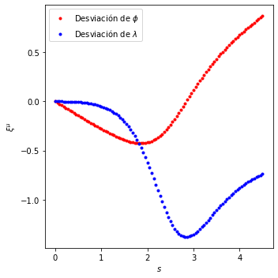

```python
#Grafica
import matplotlib.pyplot as plt
fig=plt.figure(figsize=(5,5))
ax=fig.gca()
ax.plot(ss,lats-lats2,'r.',label=r"Desviación de $\phi$")
ax.plot(ss,lons-lons2,'b.',label=r"Desviación de $\lambda$")

ax.legend()
ax.set_xlabel("$s$")
ax.set_ylabel(r"$\xi^\mu$")
fig.tight_layout()
```

**Figura 2.47.**

```python
dlats=lats-lats2
dlons=lons-lons2

dlatds=(dlats[1]-dlats[0])/(ss[1]-ss[0])
dlonds=(dlons[1]-dlons[0])/(ss[1]-ss[0])
dlatds,dlonds
```

```
(-0.2864699966151232, -0.0004717226667025898)
```

Podemos predecir a magnitud de la desviación geodésica si calculamos el tensor de Riemann para la métrica:

```python
import sympy as sp
sp.init_printing(use_unicode=True)
from einsteinpy.symbolic import *
s=sp.symbols('phi lambda')
f,l=s
f_,l_=0,1
R=sp.symbols("R")
gcomp=sp.diag(R**2,R**2*sp.cos(f)**2).tolist()
g=MetricTensor(gcomp,s)
G=ChristoffelSymbols.from_metric(g)
Riemann=RiemannCurvatureTensor.from_metric(g)
Gijk=sp.simplify(G.tensor())
Rijkl=-sp.simplify(Riemann.tensor())
```

```python
Gijk,Rijkl
```

$\displaystyle \left( \left[\begin{matrix}\left[\begin{matrix}0 & 0\\0 & \frac{\sin{\left(2 \phi \right)}}{2}\end{matrix}\right] & \left[\begin{matrix}0 & - \tan{\left(\phi \right)}\\- \tan{\left(\phi \right)} & 0\end{matrix}\right]\end{matrix}\right], \ \left[\begin{matrix}\left[\begin{matrix}0 & 0\\0 & 0\end{matrix}\right] & \left[\begin{matrix}0 & - \cos^{2}{\left(\phi \right)}\\\cos^{2}{\left(\phi \right)} & 0\end{matrix}\right]\\\left[\begin{matrix}0 & 1\\-1 & 0\end{matrix}\right] & \left[\begin{matrix}0 & 0\\0 & 0\end{matrix}\right]\end{matrix}\right]\right)$

Es decir las únicas componentes no cero son: ${R^\phi}_{\theta\phi\theta}$, ${R^\theta}_{\phi\phi\theta}$

Las ecuaciones de desviación geodésica se pueden escibrir como:

$$ \frac{D^{2} \xi^{\mu}}{D \lambda^{2}}={R^{\mu}}_{\alpha \sigma \beta} \xi^{\sigma} \frac{d x^{\alpha}}{d \lambda} \frac{d x^{\beta}}{d \lambda} $$

Que en términos del tensor de Riemann serán:

\begin{eqnarray} \nonumber \frac{D^{2} \xi^{\phi}}{D \lambda^{2}} & = & {R^{\phi}}_{\theta \phi \theta} \xi^{\phi} U^{\theta}U^{\theta}+{R^{\phi}}_{\theta \theta \phi} \xi^{\theta} U^{\theta} U^{\phi} \\ \nonumber & = & -\cos^2\theta U^{\theta}(\xi^{\phi} U^{\theta}-U^{\phi}) \\ \end{eqnarray}

Numéricamente podemos predecirlo usando la ecuación:

$$ \frac{d^{2} \xi^{\mu}}{d \lambda^{2}}=-\Gamma_{\alpha \beta, \sigma}^{\mu} \xi^{\sigma} \frac{d x^{\alpha}}{d \lambda} \frac{d x^{\beta}}{d \lambda}-2 \Gamma_{\alpha \beta}^{\mu} \frac{d \xi^{\alpha}}{d \lambda} \frac{d x^{\beta}}{d \lambda} $$

Para poder calcularlo necesito tener las derivadas de los símbolos de Christoffel:

```python
def Gammap_sym(gcomp,symbols):
    from einsteinpy.symbolic import MetricTensor,ChristoffelSymbols,BaseRelativityTensor
    from sympy import diff
    g=MetricTensor(gcomp.tolist(),symbols)
    G=ChristoffelSymbols.from_metric(g)
    Gijk=G.tensor()
    Gijk_m=[]
    for m in range(2):
        Gijk_m+=[diff(Gijk,s[m])]
    Gp=BaseRelativityTensor(Gijk_m,syms=s,config="ulll")
    var,Gfun=G.tensor_lambdify()
    var,Gpfun=Gp.tensor_lambdify()
    return Gfun,Gpfun
```

La ecuación de desviación geodésica será:

```python
def desviacion_geodesica(Y,s,Gfun,Gpfun,N=4):
    """
    Opciones:
        Gfun: símbolos de Christoffel
        Gpfun: derivada de los símbolos de Christoffel
        N: Número de dimensiones
    """
    from export import Gamma
    from numpy import zeros_like
    dYds=zeros_like(Y)

    #Extraemos los valores
    x=Y[0*N:1*N]
    dxds=Y[1*N:2*N]

    z=Y[2*N:3*N]
    dzds=Y[3*N:4*N]

    #Calcula símbolo de Christoffel
    G=array(Gfun(*x))
    Gp=array(Gpfun(*x))

    #dxds
    dYds[0*N:1*N]=dxds
    #dzds
    dYds[2*N:3*N]=dzds

    for pi in range(N):
        for mu in range(N):
            for nu in range(N):
                #d2xds2
                dYds[N+pi]+=-G[pi][mu][nu]*dxds[mu]*dxds[nu]
                #d2zds2 (parte 1)
                dYds[3*N+pi]+=-2*G[pi][mu][nu]*dzds[mu]*dxds[nu]

    for pi in range(N):
        for alfa in range(N):
            for beta in range(N):
                for sigma in range(N):
                    dYds[3*N+pi]+=-Gp[pi][alfa][beta][sigma]*z[sigma]*dxds[alfa]*dxds[beta]

    return dYds
```

Calculamos los símbolos de Christoffel y sus derivadas para la métrica de interés:

```python
def Gpfun_esf2d(R):
    from export import Gamma_sym
    from sympy import symbols,diag,cos
    s=symbols('f,l')
    f,l=s
    gcomp=diag(R**2,R**2*cos(f)**2)
    Gfun,Gpfun=Gammap_sym(gcomp,s)
    return Gfun,Gpfun
```

Integramos:

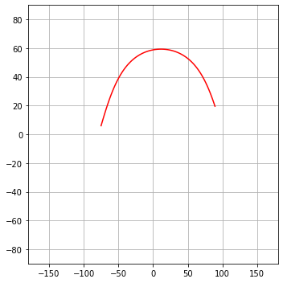

```python
N=2
R=1
ss=linspace(0,4.5,100)
Gfun,Gpfun=Gpfun_esf2d(1)

#Geodésica
Y0s=array([6*pi/180,-75*pi/180,0.5,0.3,0.0,0.0,dlatds,dlonds])
Ys=odeint(desviacion_geodesica,Y0s,ss,args=(Gfun,Gpfun,N))
lons=mod(Ys[:,1]*180/pi,360)
for i,lon in enumerate(lons):
    lons[i]=lon if lon<180 else lon-360
lats=Ys[:,0]*180/pi

#Desviación Geodésica
dlats=Ys[:,2*N]*180/pi
dlons=Ys[:,2*N+1]*180/pi

#Grafica
fig=plt.figure(figsize=(5,5))
ax=fig.gca()
ax.plot(lons,lats,'r-')

#Decoracion
ax.set_xlim((-180,180))
ax.set_ylim((-90,90))
ax.grid()
fig.tight_layout()
```

**Figura 2.48.**

Graficamos la desviación geodésica:

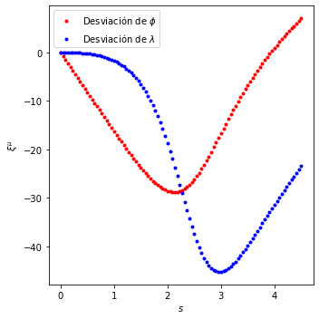

```python
#Grafica
import matplotlib.pyplot as plt
fig=plt.figure(figsize=(5,5))
ax=fig.gca()
ax.plot(ss,dlats,'r.',label=r"Desviación de $\phi$")
ax.plot(ss,dlons,'b.',label=r"Desviación de $\lambda$")

ax.legend()
ax.set_xlabel("$s$")
ax.set_ylabel(r"$\xi^\mu$")
fig.tight_layout()
```

**Figura 2.49.**

Indice | Previo: RelatividadGeneral.InerciaYGeodesicas | Siguiente: RelatividadGeneral.PrincipioConsistencia